# Assignment #4

```r
#Regular expressions
library(tidyverse)        # contains stringr for regex
library(googlesheets4)    # for reading in data
gs4_deauth()              # to read in google sheet (or download)

#tmap
library(tmap)
library(pacman)
```

```r
library(gifski)          # not needed since you won't do animated graphs

theme_set(theme_minimal()) # Lisa's favorite theme
```

When you finish the assignment, remove the `#` from the options chunk at the top, so that messages and warnings aren’t printed. If you are getting errors in your code, add `error = TRUE` so that the file knits. I would recommend not removing the `#` until you are completely finished.

## Put it on GitHub!

From now on, GitHub should be part of your routine when doing assignments. I recommend making it part of your process anytime you are working in R, but I’ll make you show it’s part of your process for assignments.

**Task**: When you are finished with the assignment, post a link below to the GitHub repo for the assignment. If you want to post it to your personal website, that’s ok (not required). Make sure the link goes to a spot in the repo where I can easily find this assignment. For example, if you have a website with a blog and post the assignment as a blog post, link to the post’s folder in the repo. As an example, I’ve linked to my GitHub stacking material [here](https://github.com/llendway/ads_website/tree/master/_posts/2021-03-22-stacking).

[Github Repo](https://github.com/willmoscato/AdvancedDataScienceHW4)

## Regular Expressions

**Tasks:**

Either read in the data using the code below (need to install `googlesheets4` library if you don’t have it) or download from [this](https://drive.google.com/file/d/12oqEt11miNGL_MtIcU75jx84pz6VEq_w/view?usp=sharing) URL and put it in your project folder.

```r
bestsellers <- read_sheet("https://docs.google.com/spreadsheets/d/1n3xKHK4-t5S73LgxOJVJWT5fMYjLj7kqmYl1LHkpk80/edit?usp=sharing")
```

```
## Reading from "bestsellers"
```

```
## Range "bestsellers"
```

**BE SURE TO REMOVE eval=FALSE** from all code sections.

1. Find books with multiple authors (HINT: Consider the possibility of an author having “and” in their name)

```r
bestsellers %>%
  mutate(mult_auth = str_detect(author, "\\sand\\s")) %>%
  filter(mult_auth == "TRUE") %>%
  summarize(title, author, mult_auth)
```

| title | author | mult_auth |
| --- | --- | --- |
| THE SENTINEL | Lee Child and Andrew Child | TRUE |
| PIECE OF MY HEART | Mary Higgins Clark and Alafair Burke | TRUE |
| MARAUDER | Clive Cussler and Boyd Morrison | TRUE |
| THREE WOMEN DISAPPEAR | James Patterson and Shan Serafin | TRUE |
| THE COAST-TO-COAST MURDERS | James Patterson and JD Barker | TRUE |
| 1ST CASE | James Patterson and Chris Tebbetts | TRUE |
| THE SUMMER HOUSE | James Patterson and Brendan DuBois | TRUE |
| MEMOIRS AND MISINFORMATION | Jim Carrey and Dana Vachon | TRUE |
| THE 20TH VICTIM | James Patterson and Maxine Paetro | TRUE |
| WRATH OF POSEIDON | Clive Cussler and Robin Burcell | TRUE |

[output cut: 224 more lines]

2. Detect if the author’s first name starts with a vowel

```r
bestsellers %>%
  mutate(vowel = str_detect(author, "^[AEIOU]")) %>%
  filter(vowel == "TRUE") %>%
  summarize(author, vowel)
```

| author | vowel |
| --- | --- |
| Ernest Cline | TRUE |
| Anthony Horowitz | TRUE |
| Elin Hilderbrand | TRUE |
| Alice Hoffman | TRUE |
| Asha Lemmie | TRUE |
| Elena Ferrante | TRUE |
| Ann Cleeves | TRUE |
| Elin Hilderbrand | TRUE |
| Alex Michaelides | TRUE |
| Akwaeke Emezi | TRUE |

[output cut: 305 more lines]

3. Change all authors with the name Alexander to Alex

```r
bestsellers %>%
  mutate(names = str_replace_all(author, "Alexander", "Alex"))
```

| title | description | contributor | author | publisher | names |
| --- | --- | --- | --- | --- | --- |
| READY PLAYER TWO | In a sequel to “Ready Player One,” Wade Watts discovers a technological advancement and goes on a new quest. | by Ernest Cline | Ernest Cline | Ballantine | Ernest Cline |
| A TIME FOR MERCY | The third book in the Jake Brigance series. A 16-year-old is accused of killing a deputy in Clanton, Miss., in 1990. | by John Grisham | John Grisham | Doubleday | John Grisham |
| DEADLY CROSS | The 28th book in the Alex Cross series. An investigation of a double homicide sends Alex Cross to Alabama. | by James Patterson | James Patterson | Little, Brown | James Patterson |
| THE RETURN | A doctor serving in the Navy in Afghanistan goes back to North Carolina where two women change his life. | by Nicholas Sparks | Nicholas Sparks | Grand Central | Nicholas Sparks |
| THE VANISHING HALF | The lives of twin sisters who run away from a Southern Black community at age 16 diverge as one returns and the other takes on a different racial identity but their fates intertwine. | by Brit Bennett | Brit Bennett | Riverhead | Brit Bennett |
| DAYLIGHT | The F.B.I. agent Atlee Pine’s search for her twin sister overlaps with a military investigator’s hunt for someone involved in a global conspiracy. | by David Baldacci | David Baldacci | Grand Central | David Baldacci |
| WHERE THE CRAWDADS SING | In a quiet town on the North Carolina coast in 1969, a young woman who survived alone in the marsh becomes a murder suspect. | by Delia Owens | Delia Owens | Putnam | Delia Owens |
| THE LAW OF INNOCENCE | The sixth book in the Mickey Haller series. Haller defends himself when police find the body of a former client in his car’s trunk. | by Michael Connelly | Michael Connelly | Little, Brown | Michael Connelly |
| THE AWAKENING | The first book in the Dragon Heart Legacy series. Breen Kelly travels through a portal in Ireland to a land of faeries and mermaids. | by Nora Roberts | Nora Roberts | St. Martin's | Nora Roberts |
| THE SENTINEL | Jack Reacher intervenes on an ambush in Tennessee and uncovers a conspiracy. | by Lee Child and Andrew Child | Lee Child and Andrew Child | Delacorte | Lee Child and Andrew Child |

[output cut: 2595 more lines]

4. Find books that are the second book in a series

```r
bestsellers %>%
  mutate(series = str_detect(bestsellers %>% pull(description),
                             pattern = "sequel")) %>%
  filter(series == TRUE)
```

| title | description | contributor | author | publisher | series |
| --- | --- | --- | --- | --- | --- |
| READY PLAYER TWO | In a sequel to “Ready Player One,” Wade Watts discovers a technological advancement and goes on a new quest. | by Ernest Cline | Ernest Cline | Ballantine | TRUE |
| THE TESTAMENTS | In a sequel to “The Handmaid’s Tale,” old secrets bring three women together as the Republic of Gilead’s theocratic regime shows signs of decay. | by Margaret Atwood | Margaret Atwood | Nan A. Talese/Doubleday | TRUE |
| WHAT HAPPENS IN PARADISE | In the sequel to "Winter in Paradise," Irene Steele visits the island of St. John to get to the bottom of the mysterious life and death of her husband. | by Elin Hilderbrand | Elin Hilderbrand | Little, Brown | TRUE |
| THE NEXT PERSON YOU MEET IN HEAVEN | The sequel to "The Five People You Meet in Heaven" follows Annie on her heavenly journey. | by Mitch Albom | Mitch Albom | Harper | TRUE |
| AFTER YOU | In a sequel to “Me Before You,” Louisa Clark tries to put her life back together after the death of Will Traynor. | by Jojo Moyes | Jojo Moyes | Pamela Dorman/Viking | TRUE |
| THE LAST MILE | In a sequel to “Memory Man,” Amos Decker helps the F.B.I. investigate the case of a killer who wins a reprieve. | by David Baldacci | David Baldacci | Grand Central | TRUE |
| EVERYBODY'S FOOL | We’re back in North Bath, N.Y., in a sequel to “Nobody’s Fool.” | by Richard Russo | Richard Russo | Knopf | TRUE |
| BEYOND THE ICE LIMIT | In a sequel to “The Ice Limit” (2000), Gideon Crew pursues a meteorite that has sunk to the ocean floor. Or is it only a meteorite? | by Douglas Preston and Lincoln Child | Douglas Preston and Lincoln Child | Grand Central | TRUE |
| THE BANDS OF MOURNING | A sequel to “Shadows of Self”; a Mistborn novel. | by Brandon Sanderson | Brandon Sanderson | Tor/Tom Doherty | TRUE |
| SECONDHAND SOULS | In a sequel to “A Dirty Job,” Charlie Asher, a Death Merchant, must stop souls in San Francisco from disappearing, even though he is trapped in a 14-inch body. | by Christopher Moore | Christopher Moore | Morrow/HarperCollins | TRUE |

[output cut: 17 more lines]

5. Find books that are the third or fourth one in a series

```r
bestsellers %>%
  mutate(series = str_detect(bestsellers %>% pull(description),
                          pattern = "(third|fourth) book")) %>%
  filter(series == TRUE)
```

| title | description | contributor | author | publisher | series |
| --- | --- | --- | --- | --- | --- |
| A TIME FOR MERCY | The third book in the Jake Brigance series. A 16-year-old is accused of killing a deputy in Clanton, Miss., in 1990. | by John Grisham | John Grisham | Doubleday | TRUE |
| RHYTHM OF WAR | The fourth book in the Stormlight Archive series. Technological discoveries and an ensuing arms race change how a war is fought. | by Brandon Sanderson | Brandon Sanderson | Tor | TRUE |
| THE LAST DRUID | The fourth book in the Fall of Shannara series. | by Terry Brooks | Terry Brooks | Del Rey | TRUE |
| FAIR WARNING | The third book in the Jack McEvoy series. A reporter tracks a killer who uses genetic data to pick his victims. | by Michael Connelly | Michael Connelly | Little, Brown | TRUE |
| THE MIRROR & THE LIGHT | The third book in the Wolf Hall trilogy. After Anne Boleyn’s execution, Thomas Cromwell’s enemies assemble. | by Hilary Mantel | Hilary Mantel | Holt | TRUE |
| SAVAGE SON | The third book in the Terminal List series. The Russian mafia targets a former Navy SEAL who is recovering from brain surgery. | by Jack Carr | Jack Carr | Emily Bestler/Atria | TRUE |
| THE RISE OF MAGICKS | The third book in the Chronicles of the One series. Fallon Swift goes up against an old foe. | by Nora Roberts | Nora Roberts | St. Martin's | TRUE |
| THE BITTERROOTS | The fourth book in the Cassie Dewell series. The black sheep of an influential family is accused of assault. | by C.J. Box | C J Box | Minotaur | TRUE |
| SKIN GAME | The third book in the Teddy Fay series. Teddy Fay scours Paris’s underworld to find a treasonous criminal. | by Stuart Woods and Parnell Hall | Stuart Woods and Parnell Hall | Putnam | TRUE |
| THE STIEHL ASSASSIN | The third book in the Fall of Shannara series. | by Terry Brooks | Terry Brooks | Del Rey | TRUE |

[output cut: 14 more lines]

6. Find books that are the 10th, 11th, …, or 19th book in a series

```r
bestsellers %>%
  mutate(series = str_detect(bestsellers %>% pull(description),
                          pattern = "1[0-9]th book")) %>%
  filter(series == TRUE)
```

| title | description | contributor | author | publisher | series |
| --- | --- | --- | --- | --- | --- |
| MARAUDER | The 15th book in the Oregon Files series. A billionaire's dying wish bestows a paralyzing chemical to a terrorist group. | by Clive Cussler and Boyd Morrison | Clive Cussler and Boyd Morrison | Putnam | TRUE |
| BATTLE GROUND | The 17th book in the Dresden Files series. Harry must save Chicago from destruction by the Last Titan. | by Jim Butcher | Jim Butcher | Ace | TRUE |
| NEXT TO LAST STAND | The 16th book in the Longmire series. A million dollars in a shoebox and a piece of a painting might be clues to an art heist. | by Craig Johnson | Craig Johnson | Viking | TRUE |
| ALL THE DEVILS ARE HERE | The 16th book in the Chief Inspector Gamache series. When his billionaire godfather is attacked, Gamache uncovers secrets hidden throughout Paris. | by Louise Penny | Louise Penny | Minotaur | TRUE |
| NEAR DARK | The 19th book in the Scot Harvath series. With a bounty on his head, Harvath makes an alliance with a Norwegian intelligence operative. | by Brad Thor | Brad Thor | Emily Bestler/Atria | TRUE |
| THE SILENT WIFE | The 10th book in the Will Trent series. Investigations of two crimes force Trent to call on his girlfriend's expertise as a medical examiner. | by Karin Slaughter | Karin Slaughter | Morrow | TRUE |
| PEACE TALKS | The 16th book in the Dresden Files series. Chicago's only professional wizard tries to keep the peace during a summit of the Supernatural nations of the world. | by Jim Butcher | Jim Butcher | Ace | TRUE |
| WRATH OF POSEIDON | The 12th book in the Sam and Remi Fargo Adventure series. A kingpin is released from prison and a final showdown takes place in Greece. | by Clive Cussler and Robin Burcell | Clive Cussler and Robin Burcell | Putnam | TRUE |
| BLINDSIDE | The 12th book in the Michael Bennett series. A serial-killing spree might impact national security. | by James Patterson and James O. Born | James Patterson and James O Born | Little, Brown | TRUE |
| THE LAST ODYSSEY | The 15th book in the Sigma Force series. Catastrophic dangers might be set in motion when a medieval ship is discovered in Greenland. | by James Rollins | James Rollins | Morrow | TRUE |

[output cut: 32 more lines]

7. Describe in your own words how you would go about writing a regular expression for password pattern matching (ie 8 character minimum, one capital letter minimum, one lowercase letter minimum, one digit minimum, one special character minimum)

**I’m not entirely sure, but I think that you would have to use str_locate a bunch of times and have it search for first where the lowercase letters are, then once you have those the uppercase letters, then the numbers, then the special characters.**

## `tmap` exercises

Read in the data:

```r
data("World")
```

In addition to the World data, we will use data called **metro** that comes from the `tmap` package. It contains metropolitan area information from major cities across the globe. Some important variables include:

- **Name** : city name
- **pop2010** : population in 2010
- **pop2020** : population in 2020

```r
data("metro")
```

**!!!!!!REMEMBER TO REMOVE eval=FALSE!!!!!!!!!!!**

1. Make a world map using the base **World** dataset we used with the COVID example. Add information about income groups (income_grp) to the plot, specify a color palette.

```r
# let's explore the variable names of each dataset
names(World)
```

```
##  [1] "iso_a3"       "name"         "sovereignt"   "continent"    "area"
##  [6] "pop_est"      "pop_est_dens" "economy"      "income_grp"   "gdp_cap_est"
## [11] "life_exp"     "well_being"   "footprint"    "inequality"   "HPI"
## [16] "geometry"
```

```r
names(metro)
```

```
##  [1] "name"      "name_long" "iso_a3"    "pop1950"   "pop1960"   "pop1970"
##  [7] "pop1980"   "pop1990"   "pop2000"   "pop2010"   "pop2020"   "pop2030"
## [13] "geometry"
```

```r
tmap_mode('plot')
```

```
## tmap mode set to plotting
```

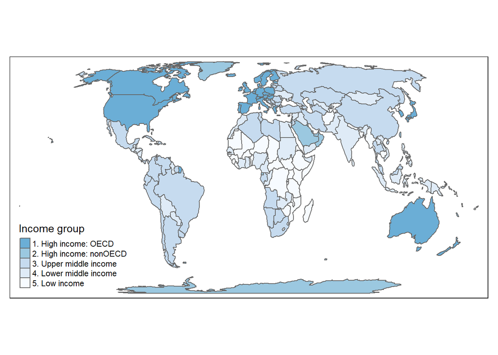

```r
tm_shape(World) +
    tm_polygons("income_grp",
                palette="-Blues",
                contrast= .5,
                id="name",
                title="Income group")
```

2. To the plot from (1), add the new dataset **metro** to the plot, and add information about cities’ populations in 2020.

```r
tmap_mode('plot')
```

```
## tmap mode set to plotting
```

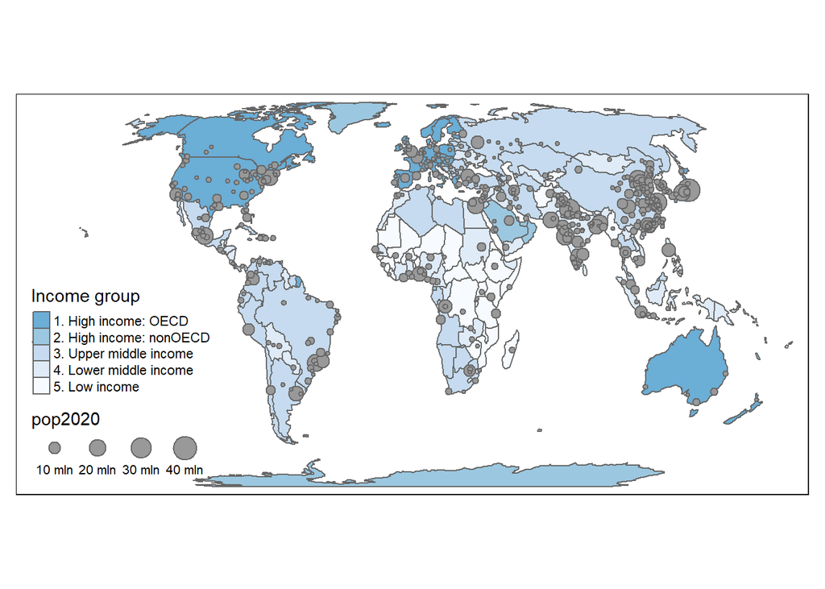

```r
tm_shape(World) +
    tm_polygons("income_grp", palette="-Blues", contrast= .5, id="name", title="Income group") +
  tm_shape(metro) +
  tm_bubbles("pop2020")
```

3. Now, make a new plot with the World data that provides a look at country economic status and the inequality associated with each.

```r
# Set your mode
tmap_mode('plot')
```

```
## tmap mode set to plotting
```

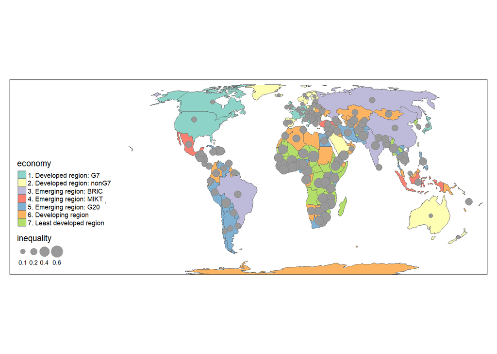

```r
tm_shape(World) +
  tm_polygons("economy") +
  tm_bubbles("inequality", border.alpha = .5) +
  tm_format("World_wide")
```

4. Using a new data set, NDL_muni municipality data from the Netherlands, create a plot with two separate maps. One showing the percentage of men per municipality of the whole country, and one showing the same but faceted by **province**.

```r
tmap_mode("plot")
```

```
## tmap mode set to plotting
```

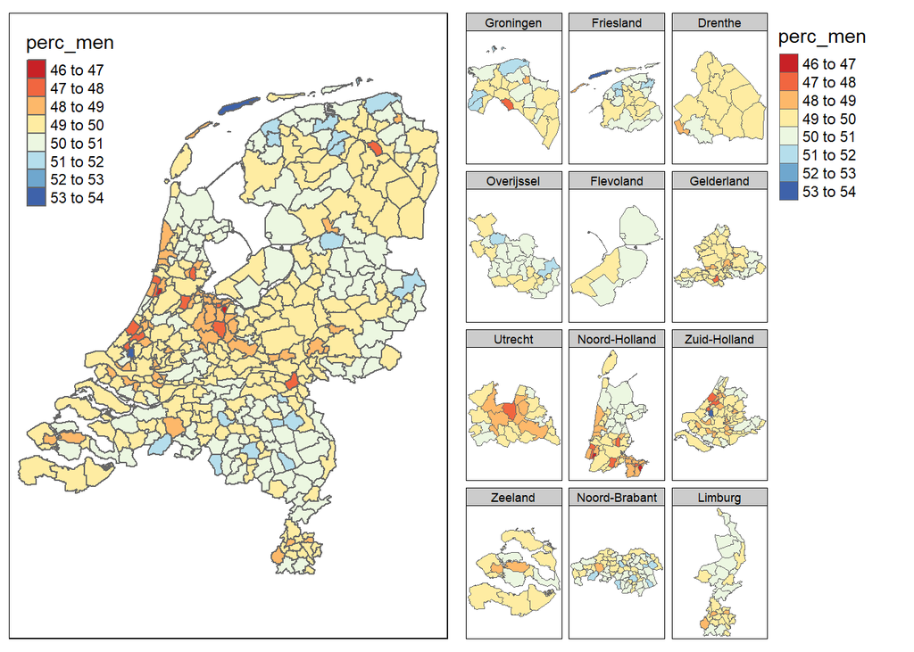

```r
data(NLD_muni)

NLD_muni$perc_men <- NLD_muni$pop_men / NLD_muni$population * 100

tm1 <- tm_shape(NLD_muni) + tm_polygons("perc_men", palette = 'RdYlBu')

tm2 <- tm_shape(NLD_muni) +
    tm_polygons("perc_men", palette = "RdYlBu") +
    tm_facets(by = "province")

tmap_arrange(tm1, tm2)
```

## Data Ethics: Data visualization principles

I’m hoping that the topic for this week is a review for all of you, but it’s good to remind ourselves of these principles.

**Task:**

Read both short articles in Week6. Data visualization section of [Calling Bulllshit](https://www.callingbullshit.org/syllabus.html#Visual). Were there any principles mentioned that you hadn’t heard of before? What graph stood out for you as “the worst”? Did any of the graphs fool you? Or were able to overcome the bad practices (don’t worry if they fool you - plently of them have fooled me, too.)? How does practicing good data visualization principles fit in with data ethics?

**The worst graph that stood out to me before and has stood out to me in the past is the one showing gun deaths in Florida. The fact that it is upside down makes it seem that the gun deaths are decreasing when they are in fact increasing. The visualization shows the opposite of what the data is saying. I think that the big take aways that I had from both these articles is that you have to pay attention to the trends and the context of the trends that you are trying to show in order to make a visualization that makes sense.**